# STA 5207: Homework 4

Due: Friday, February 9 by 11:59 PM

Include your R code in an R chunks as part of your answer. In addition, your written answer to each exercise should be self-contained so that the grader can determine your solution without reading your code or deciphering its output

## Exercise 1 (Average Treatment Effect) [25 Points]

For this exercise we will use a subset of the `hips` data set from the `faraway` package, which can be found in `hips_subset.csv` on Canvas. This data set contains data used to study a new treatment for Ankylosing spondylitis (AS), which is a chronic form of arthritis. A study was conducted to determine whether daily stretching of the hip tissues would improve mobility. There are 75 AS patients who where randomly allocated to a control (standard treatment) or a treatment (the new treatment) group. The data set contains three variables:

- `fbef` : flexion angle before
- `faft`: flexion angle after.
- `grp`: treatment group. A factor with levels `control` (individuals received the standard treatment) and `treat` (individuals received a new treatment).

In this exercise, we will determine if there is a statistically significant *average treatment effect*, that is, whether there is a difference in the average value of `faft` between individuals in the `treat` and `control` group who started with the same value of `fbef`.

1. (2 points) Load the data and check its structure using `str()`. Verify that `grp` is a factor. If not, coerce it to be a factor. Include your code and its output below. What is the default reference level chosen by `R`?

   ```r
   data = read.csv("hips_subset.csv")
   str(data)
   ```

   ```
   ## 'data.frame':    75 obs. of  3 variables:
   ##  $ fbef: int  125 120 135 135 100 110 122 122 124 124 ...
   ##  $ faft: int  126 127 135 135 113 115 123 125 126 135 ...
   ##  $ grp : chr  "treat" "treat" "treat" "treat" ...
   ```

   ```r
   is.factor(data$grp)
   ```

   ```
   ## [1] FALSE
   ```

   ```r
   data$grp =  as.factor(data$grp)
   is.factor(data$grp)
   ```

   ```
   ## [1] TRUE
   ```

   ```r
   str(data)
   ```

   ```
   ## 'data.frame':    75 obs. of  3 variables:
   ##  $ fbef: int  125 120 135 135 100 110 122 122 124 124 ...
   ##  $ faft: int  126 127 135 135 113 115 123 125 126 135 ...
   ##  $ grp : Factor w/ 2 levels "control","treat": 2 2 2 2 2 2 2 2 2 2 ...
   ```

   The reference level of grp is control.
2. (2 points) Using the plotting functions discussed in class, make a scatter plot of `faft` versus `fbef` . Use a different color point and shape for each level of `grp`. Also be sure to label the axes appropriately and include a legend. Based on the scatter plot, does the linear relationship between `faft` and `fbef` seem to differ between treatment groups? Briefly explain.

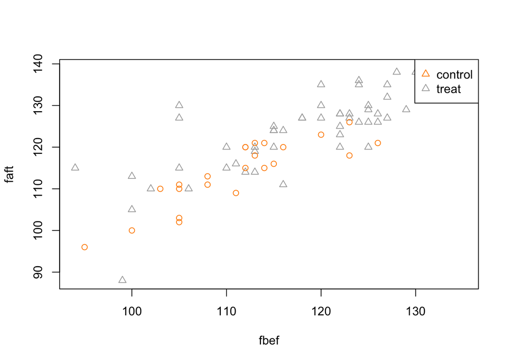

   ```r
   plot_colors = c("Darkorange", "Darkgrey")

   plot(faft ~ fbef, data = data,
        col = plot_colors[grp],  pch = as.numeric(grp),
        xlab = "fbef", ylab = "faft")

   # Add legend
   legend("topright", legend = levels(factor(data$grp)),
          col = unique(plot_colors), pch = as.numeric(data$grp))
   ```

   It does seem like the linear relationship between fbef and faft differ between treatment groups. The line for treat seems to be slightly higher, indicating a higher intercept. There is no easily observable difference between the slope.
3. (4 points) Fit a simple linear regression model with `faft` as the response and `fbef` as the predictor. Give the estimated regression equation.

   ```r
   model = lm(faft ~ fbef, data = data)
   summary(model)$coefficients
   ```

   ```
   ##               Estimate Std. Error  t value     Pr(>|t|)
   ## (Intercept) 19.7321226 8.30619880  2.37559 2.014778e-02
   ## fbef         0.8726813 0.07141478 12.21990 2.503684e-19
   ```

   $$faft = 19.732 + .872(fbef)$$
4. (3 points) Using the plotting functions discussed in class, make a scatter plot of `faft` versus `fbef`. Use a different color point and shape for each level of `grp`. Also be sure to label the axes appropriately and include a legend. Add the fitted regression line from the SLR model you estimated in Question 3 to the scatter plot. Comment on how well this line models the data.

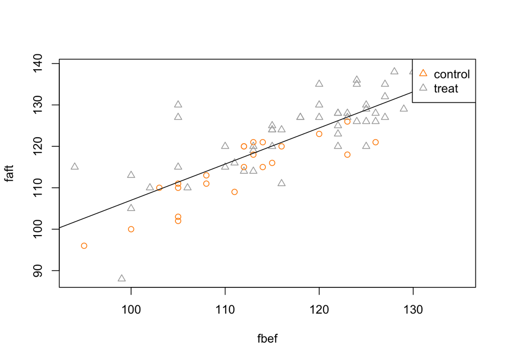

   ```r
   plot_colors = c("Darkorange", "Darkgrey")

   plot(faft ~ fbef, data = data,
        col = plot_colors[grp],  pch = as.numeric(grp),
        xlab = "fbef", ylab = "faft")

   abline(model)

   # Add legend
   legend("topright", legend = levels(factor(data$grp)),
          col = unique(plot_colors), pch = as.numeric(data$grp))
   ```

   The fitted line fits well but it is clear that there are outliers depending on the treatment. We are underestimating the treat group and over estimating the control group.
5. (5 points) Fit an additive multiple regression model with `faft` as the response and `fbef` and `grp` as the predictors. Give the two separate estimated regression equations for the `control` and `treat` groups.

   ```r
   model1 = lm(faft ~ fbef + grp, data = data)
   coef(model1)
   ```

   ```
   ## (Intercept)        fbef    grptreat
   ##  25.1914193   0.7973406   4.7223852
   ```

   ```r
   (int_control = coef(model1)[1])
   ```

   ```
   ## (Intercept)
   ##    25.19142
   ```

   ```r
   (int_treat = coef(model1)[1] + coef(model1)[3])
   ```

   ```
   ## (Intercept)
   ##     29.9138
   ```

   ```r
   (slope_all_species = coef(model1)[2])
   ```

   ```
   ##      fbef
   ## 0.7973406
   ```

   $$\begin{cases}
   faft = 25.191 + .797fbef & \text{for control}\\
   faft = 29.914 + .797fbef & \text{for treat}
   \end{cases}$$
6. (3 points) Using the plotting functions discussed in class, make a scatter plot of `faft` versus `fbef`. Use a different color point and shape for each level of `grp`. Also be sure to label the axes appropriately and include a legend. Add the two fitted regression lines from the additive model to the scatter plot with the same colors as their respective points (one line for each level of `grp`). Comment on how well these lines model the data.

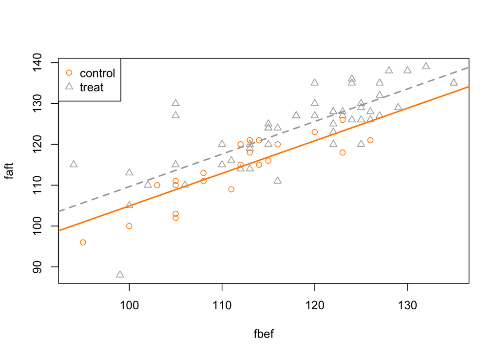

   ```r
   plot_colors = c("Darkorange", "Darkgrey")

   plot(faft ~ fbef, data = data,
        col = plot_colors[grp],  pch = as.numeric(grp),
        xlab = "fbef", ylab = "faft")


   # NEW: ablines take the intercept and slope of each regression line calculated above
   abline(int_control, slope_all_species, col= plot_colors[1], lty = 1, lwd = 2)
   abline(int_treat, slope_all_species, col = plot_colors[2], lty = 2, lwd = 2)

   legend("topleft", levels(data$grp), col=plot_colors,  pch = c(1, 2, 3))
   ```

   This line fits better than the standard model. But it is clear that there is underestimating and overestimating for both indicating the slope may be different for the two groups.
7. (6 points) Use an appropriate test to determine whether there is a significant average treatment effect, that is, perform a test to compare the model from Question 3 to the model from Question 5. Report the following:
   - The null and alternative hypotheses.
   - The value of the test statistic.
   - The $p$-value of the test.
   - A statistical decision at $\alpha = 0.01$.
   - A conclusion in the context of the problem.

   ```r
   anova(model, model1)
   ```

   |  | Res.Df | RSS | Df | Sum of Sq | F | Pr(>F) |
   | --- | --- | --- | --- | --- | --- | --- |
   | 1 | 73 | 2524.050 | NA | NA | NA | NA |
   | 2 | 72 | 2206.907 | 1 | 317.1434 | 10.34676 | 0.001944184 |

Null Hypothesis: $\beta_2 = 0$

Alternative Hypothesis: $\beta_2 \neq 0$

F Statistic: 10.35

$p$-value: .0019

The $p$-value is less than .01. We reject the null hypothesis. We prefer the additive model.

## Exercise 2 (The Iris Data Set) [35 Points]

For this exercise we will use the `iris` data set. This is a default data set in `R`. You can also find the data in `iris.csv` on Canvas. This data set gives measurements of 50 flowers from 3 species of iris. The data set contains the following 4 variables:

- `Sepal.Length`: sepal length in cm.
- `Sepal.Width`: sepal width in cm.
- `Petal.Length`: petal length in cm.
- `Petal.Width`: petal width in cm.
- `Species`: The three species of iris flowers: “setosa”, “versicolor”, and “virginica”.

For this exercise, we will model `Sepal.Width` as a function of `Sepal.Length` and `Species`.

1. (2 points) Load the data and check its structure using `str()`. Verify that `species` is a factor. If not, coerce it to be a factor. Include your code and its output below. What is the default reference level chosen by `R`?

   ```r
   iris = read.csv("iris.csv")
   str(iris)
   ```

   ```
   ## 'data.frame':    150 obs. of  5 variables:
   ##  $ Sepal.Length: num  5.1 4.9 4.7 4.6 5 5.4 4.6 5 4.4 4.9 ...
   ##  $ Sepal.Width : num  3.5 3 3.2 3.1 3.6 3.9 3.4 3.4 2.9 3.1 ...
   ##  $ Petal.Length: num  1.4 1.4 1.3 1.5 1.4 1.7 1.4 1.5 1.4 1.5 ...
   ##  $ Petal.Width : num  0.2 0.2 0.2 0.2 0.2 0.4 0.3 0.2 0.2 0.1 ...
   ##  $ Species     : chr  "setosa" "setosa" "setosa" "setosa" ...
   ```

   ```r
   is.factor(iris$Species)
   ```

   ```
   ## [1] FALSE
   ```

   ```r
   iris$Species =  as.factor(iris$Species)
   is.factor(iris$Species)
   ```

   ```
   ## [1] TRUE
   ```

   ```r
   str(iris)
   ```

   ```
   ## 'data.frame':    150 obs. of  5 variables:
   ##  $ Sepal.Length: num  5.1 4.9 4.7 4.6 5 5.4 4.6 5 4.4 4.9 ...
   ##  $ Sepal.Width : num  3.5 3 3.2 3.1 3.6 3.9 3.4 3.4 2.9 3.1 ...
   ##  $ Petal.Length: num  1.4 1.4 1.3 1.5 1.4 1.7 1.4 1.5 1.4 1.5 ...
   ##  $ Petal.Width : num  0.2 0.2 0.2 0.2 0.2 0.4 0.3 0.2 0.2 0.1 ...
   ##  $ Species     : Factor w/ 3 levels "setosa","versicolor",..: 1 1 1 1 1 1 1 1 1 1 ...
   ```

   The reference level chosen is setosa.
2. (2 points) Using the plotting functions discussed in class, make a scatter plot of `Sepal.Width` versus `Sepal.Length`. Use a different color point and shape for each `Species`. Also be sure to label the axes appropriately and include a legend. Based on the scatter plot, does the linear relationship between `Sepal.Width` and `Sepal.Length` seem to differ between flower species? Briefly explain.

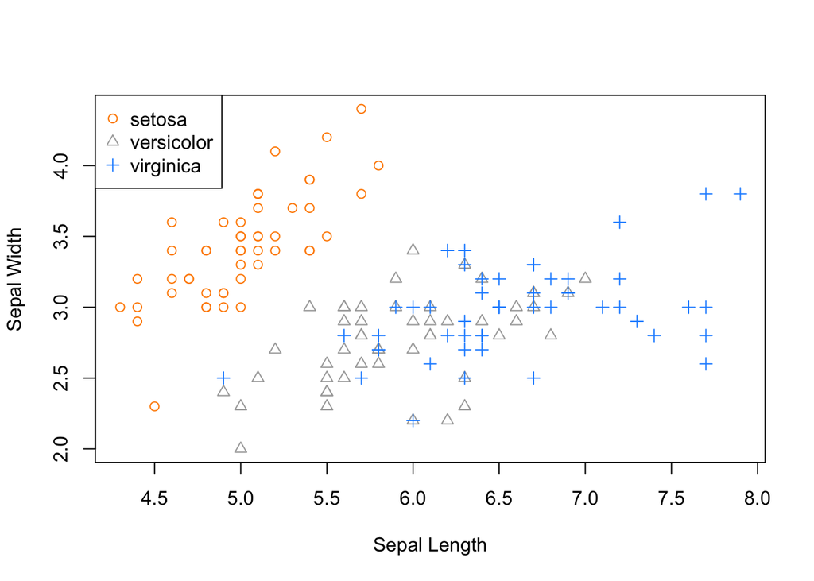

   ```r
   plot_colors = c("Darkorange", "Darkgrey", "Dodgerblue")

   plot(Sepal.Width ~ Sepal.Length, data = iris,
        col = plot_colors[Species],  pch = as.numeric(Species),
        xlab = "Sepal Length", ylab = "Sepal Width")


   legend("topleft", levels(iris$Species), col=plot_colors,  pch = c(1, 2, 3))
   ```

   It seems they differ completely. Versicolor and Virginica may have some common attributes but Setosa has no overlap.
3. (4 points) Estimate a simple linear regression model with `Sepal.Width` as the response and only `Sepal.Length` as the predictor. Give the estimated regression equation and an estimate for the average change in `Sepal.Width` for a 1 cm increase in `Sepal.Length` for `setosa` flowers.

   ```r
   iris_model = lm(Sepal.Width ~ Sepal.Length, data = iris)
   coef(iris_model)
   ```

   ```
   ##  (Intercept) Sepal.Length
   ##    3.4189468   -0.0618848
   ```

   $$\text{Sepal.Width}
   = 3.42 - .062\text{Sepal.Length}$$
4. (3 points) Using the plotting functions discussed in class, make a scatter plot of `Sepal.Width` versus `Sepla.Length`. Use a different color point and shape for each `Species`. Also be sure to label the axes appropriately and include a legend. Add the fitted regression line for the SLR model you estimated in Question 3 to the scatter plot. Comment on how well this line models the data.

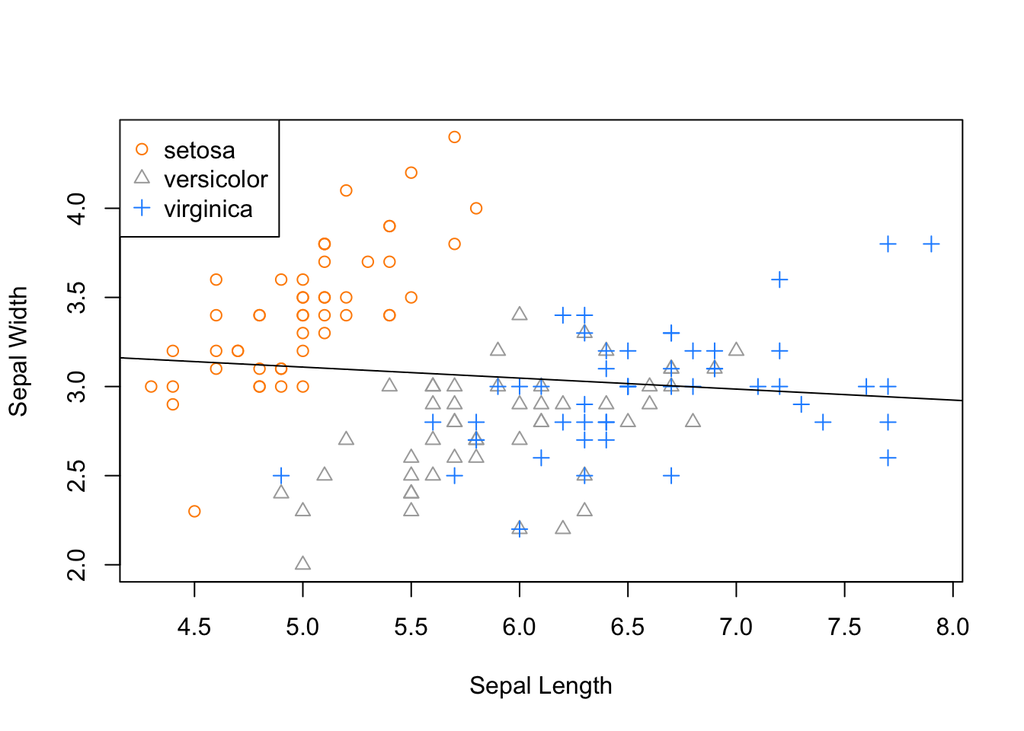

   ```r
   plot_colors = c("Darkorange", "Darkgrey", "Dodgerblue")

   plot(Sepal.Width ~ Sepal.Length, data = iris,
        col = plot_colors[Species],  pch = as.numeric(Species),
        xlab = "Sepal Length", ylab = "Sepal Width")

   abline(iris_model)


   legend("topleft", levels(iris$Species), col=plot_colors,  pch = c(1, 2, 3))
   ```

   The line does not fit well at all. We are drastically underestimating Setosa, and overestimating both Versicolor and Virginica.
5. (4 points) Fit an additive multiple regression model with `Sepal.Width` as the response and `Sepal.Length` and `Species` as the predictors. Give the three separate estimated regression equations for `setosa`, `versicolor`, and `virginica` flowers. Also, give an estimate for the average change in `Sepal.Width` for a 1 cm increase in `Sepal.Length` for `setosa` flowers.

   ```r
   iris_model_add = lm(Sepal.Width ~ Sepal.Length + Species, data = iris)
   coef(iris_model_add)
   ```

   ```
   ##       (Intercept)      Sepal.Length Speciesversicolor  Speciesvirginica
   ##         1.6765001         0.3498801        -0.9833885        -1.0075104
   ```

   ```r
   (int_setosa = coef(iris_model_add)[1])
   ```

   ```
   ## (Intercept)
   ##      1.6765
   ```

   ```r
   (int_versicolor = coef(iris_model_add)[1] + coef(iris_model_add)[3])
   ```

   ```
   ## (Intercept)
   ##   0.6931116
   ```

   ```r
   (int_virginica = coef(iris_model_add)[1] + coef(iris_model_add)[4])
   ```

   ```
   ## (Intercept)
   ##   0.6689898
   ```

   ```r
   (slope_all_species = coef(iris_model_add)[2])
   ```

   ```
   ## Sepal.Length
   ##    0.3498801
   ```

   $$\begin{cases}
   \text{Sepal.Width} = 1.68 + .35\text{Sepal.Length} & \text{for
   Setosa}\\
   \text{Sepal.Width} = .69 + .35\text{Sepal.Length} & \text{for
   Versicolor}\\
   \text{Sepal.Width} = .67 + .35\text{Sepal.Length} & \text{for
   Virginica}\\
   \end{cases}$$
6. (3 points) Using the plotting functions discussed in class, make a scatter plot of `Sepal.Width` versus `Sepal.Length`. Use a different color point and shape for each `Species`. Also be sure to label the axes appropriately and include a legend. Add the three fitted regression lines from the additive model to the scatter plot with the same colors as their respective points (one line for each species type). Comment on how well these lines model the data.

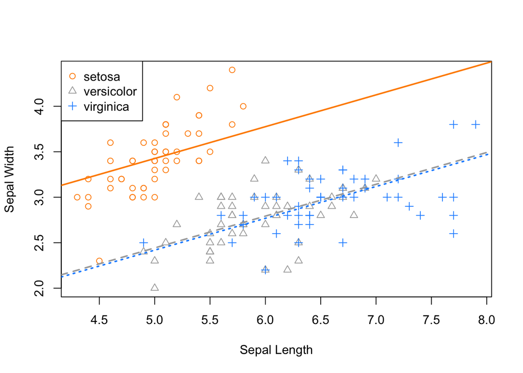

   ```r
   plot_colors = c("Darkorange", "Darkgrey", "Dodgerblue")

   plot(Sepal.Width ~ Sepal.Length, data = iris,
        col = plot_colors[Species],  pch = as.numeric(Species),
        xlab = "Sepal Length", ylab = "Sepal Width")

   # NEW: ablines take the intercept and slope of each regression line calculated above
   abline(int_setosa, slope_all_species, col= plot_colors[1], lty = 1, lwd = 2)
   abline(int_versicolor, slope_all_species, col = plot_colors[2], lty = 2, lwd = 2)
   abline(int_virginica, slope_all_species, col = plot_colors[3], lty = 3, lwd = 2)

   legend("topleft", levels(iris$Species), col=plot_colors,  pch = c(1, 2, 3))
   ```

   These lines fit the data much better. There is some underestimating and overestimating for Versicolor and Virginica. Suggesting different intercepts but it is much better.
7. (5 points) Use an appropriate test to compare the SLR model from Question 3 to the additive model in Question 5 at an $\alpha = 0.01$ significance level. Report the following:
   - The null and alternative hypotheses.
   - The value of the test statistic.
   - The $p$-value of the test.
   - The model you prefer based on the results of the test

   ```r
   anova(iris_model, iris_model_add)
   ```

   |  | Res.Df | RSS | Df | Sum of Sq | F | Pr(>F) |
   | --- | --- | --- | --- | --- | --- | --- |
   | 1 | 148 | 27.91566 | NA | NA | NA | NA |
   | 2 | 146 | 12.19313 | 2 | 15.72252 | 94.13036 | 5.489434e-27 |

   Null Hypothesis: $\beta_2 = 0$

   Alternative Hypothesis: $\beta_2 \neq 0$

   F Statistic: 94.13

   $p$-value: $5.49 \times e^{-27}$

   The $p$-value is less than .01. We reject the null hypothesis. We prefer the additive model.
8. (4 points) Fit an interaction MLR model with `Sepal.Width` as the response and `Sepal.Length` and `Species` as the predictors. Give the three separate estimated regression equations for `setosa`, `versicolor`, and `virginica` flowers. Also, give an estimate for the average change in `Sepal.Width` for a 1 cm increase in `Sepal.Length` for `setosa` flowers.

   ```r
   model_int = lm(Sepal.Width ~ Sepal.Length * Species, data = iris)
   coef(model_int)
   ```

   ```
   ##                    (Intercept)                   Sepal.Length
   ##                     -0.5694327                      0.7985283
   ##              Speciesversicolor               Speciesvirginica
   ##                      1.4415786                      2.0157381
   ## Sepal.Length:Speciesversicolor  Sepal.Length:Speciesvirginica
   ##                     -0.4788090                     -0.5666378
   ```

   ```r
   (int_setosa = coef(model_int)[1])
   ```

   ```
   ## (Intercept)
   ##  -0.5694327
   ```

   ```r
   (int_versicolor = coef(model_int)[1] + coef(model_int)[3])
   ```

   ```
   ## (Intercept)
   ##    0.872146
   ```

   ```r
   (int_virginica = coef(model_int)[1] + coef(model_int)[4])
   ```

   ```
   ## (Intercept)
   ##    1.446305
   ```

   ```r
   (slope_setosa =  coef(model_int)[2])
   ```

   ```
   ## Sepal.Length
   ##    0.7985283
   ```

   ```r
   (slope_versicolor = coef(model_int)[2] + coef(model_int)[5])
   ```

   ```
   ## Sepal.Length
   ##    0.3197193
   ```

   ```r
   (slope_virginica = coef(model_int)[2] + coef(model_int)[6])
   ```

   ```
   ## Sepal.Length
   ##    0.2318905
   ```

   $$\begin{cases}
   \text{Sepal.Width} = -.57 + .8\text{Sepal.Length} & \text{for
   Setosa}\\
   \text{Sepal.Width} = .87 + .32\text{Sepal.Length} & \text{for
   Versicolor}\\
   \text{Sepal.Width} = 1.45 + .23\text{Sepal.Length} & \text{for
   Virginica}\\
   \end{cases}$$

   The estimated average change in Sepal.Width for a 1 cm increase in Sepal.Length for the Setosa flowers is .8 cm.
9. (3 points) Using the plotting functions discussed in class, make a scatter plot of `Sepal.Width` versus `Sepal.Length`. Use a different color point and shape for each `Species`. Also be sure to label the axes appropriately and include a legend. Add the three fitted regression lines from the interaction model to the scatter plot with the same colors as their respective points (one line for each species type). Comment on how well these lines model the data.

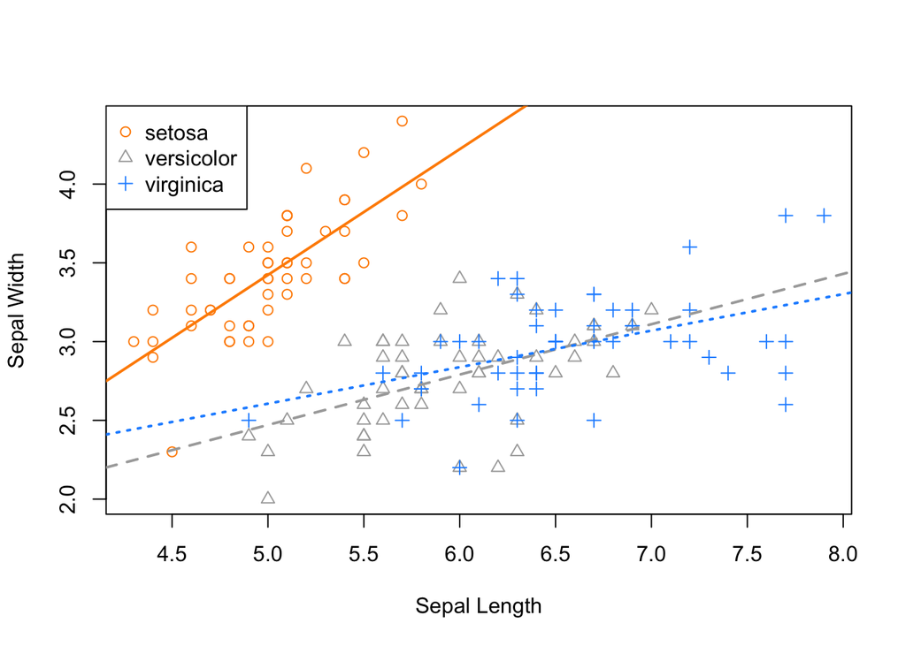

   ```r
   plot_colors = c("Darkorange", "Darkgrey", "Dodgerblue")

   plot(Sepal.Width ~ Sepal.Length, data = iris,
        col = plot_colors[Species],  pch = as.numeric(Species),
        xlab = "Sepal Length", ylab = "Sepal Width")

   # NEW: ablines take the intercept and slope of each regression line calculated above
   abline(int_setosa, slope_setosa, col= plot_colors[1], lty = 1, lwd = 2)
   abline(int_versicolor, slope_versicolor, col = plot_colors[2], lty = 2, lwd = 2)
   abline(int_virginica, slope_virginica, col = plot_colors[3], lty = 3, lwd = 2)

   legend("topleft", levels(iris$Species), col=plot_colors,  pch = c(1, 2, 3))
   ```

   These lines fit much better than the additive model. All three lines model the data very well.
10. (5 points) Use an appropriate test to compare the additive model from Question 5 to the interaction model in Question 8 at an $\alpha = 0.01$ significance level. Report the following:
    - The null and alternative hypotheses.
    - The value of the test statistic.
    - The $p$-value of the test.
    - The model you prefer based on the results of the test.

```r
anova(iris_model_add, model_int)
```

|  | Res.Df | RSS | Df | Sum of Sq | F | Pr(>F) |
| --- | --- | --- | --- | --- | --- | --- |
| 1 | 146 | 12.19313 | NA | NA | NA | NA |
| 2 | 144 | 10.67997 | 2 | 1.513165 | 10.20114 | 7.190074e-05 |

- Null Hypothesis: $\beta_2 = 0$
- Alternative Hypothesis: $\beta_2 \neq 0$
- F Statistic: 10.2
- $p$-value: $7.19 \times e^{-05}$
- The $p$-value is less than .01. We reject the null hypothesis. We prefer the interaction model.

## Exercise 3 (2015 EPA Emissions Data Set) [40 Points]

For this exercise we will use the `epa` data set, which can be found in the `epa.csv` file on Canvas. This data set contains detailed descriptions of 4,411 vehicles manufactured in 2015 that were used for fuel economy testing as performed by the Environmental Projection Agency. The variables in the dataset are:

- `CO2`: carbon dioxide (the primary byproduct of all fossil fuel combustion), in g/mi.
- `horse`: rated horsepower, in foot-pounds per second.
- `type`: vehicle type: Car, Truck, or Both (for vehicles that meet specifications of both car and truck, like smaller SUVs or crossovers).

In this exercise, we will model `CO2` a a function of `horse` and `type`.

1. (2 points) Load the data and check its structure using `str()`. Verify that `type` is a factor. If not, coerce it to be a factor. Include your code and its output below. What is the default reference level chosen by `R`?

   ```r
   epa = read.csv("epa.csv")
   str(epa)
   ```

   ```
   ## 'data.frame':    4411 obs. of  3 variables:
   ##  $ CO2  : num  550 344 512 297 603 ...
   ##  $ horse: int  510 510 552 552 565 565 420 420 430 430 ...
   ##  $ type : chr  "Car" "Car" "Car" "Car" ...
   ```

   ```r
   is.factor(epa$type)
   ```

   ```
   ## [1] FALSE
   ```

   ```r
   epa$type =  as.factor(epa$type)
   is.factor(epa$type)
   ```

   ```
   ## [1] TRUE
   ```

   ```r
   str(epa)
   ```

   ```
   ## 'data.frame':    4411 obs. of  3 variables:
   ##  $ CO2  : num  550 344 512 297 603 ...
   ##  $ horse: int  510 510 552 552 565 565 420 420 430 430 ...
   ##  $ type : Factor w/ 3 levels "Both","Car","Truck": 2 2 2 2 2 2 2 2 2 2 ...
   ```

   The default reference level is Both.
2. (2 points) Using the plotting functions discussed in class, make a scatter plot of `CO2` versus `horse`. Use a different color point and shape for each vehicle `type`. Also be sure to label the axes appropriately and include a legend. Based on the scatter plot, does the linear relationship between `CO2` and `horse` seem to differ between vehicle type? Briefly explain.

[figure not shown]

   ```r
   plot_colors = c("Darkorange", "Darkgrey", "Dodgerblue")

   plot(CO2 ~ horse, data = epa,
        col = plot_colors[type],  pch = as.numeric(type),
        xlab = "CO2", ylab = "Horsepower")


   legend("topleft", levels(epa$type), col=plot_colors,  pch = c(1, 2, 3))
   ```

   There seems to be a linear relationship between CO2 and Horsepower for every type of vehicle.
3. (4 points) Estimate a simple linear regression model with `CO2` as the response and only `horse` as the predictor. Give the estimated regression equation and an estimate for the average change in `CO2` for a one foot-pound per second increase in `horse` for a vehicle of type `Truck`.

   ```r
   epa_model = lm(CO2 ~ horse, data = epa)
   coef(epa_model)
   ```

   ```
   ## (Intercept)       horse
   ## 154.7178499   0.5498996
   ```

[figure not shown]

   ```r
   plot_colors = c("Darkorange", "Darkgrey", "Dodgerblue")

   plot(CO2 ~ horse, data = epa,
        col = plot_colors[type],  pch = as.numeric(type),
        xlab = "CO2", ylab = "Horsepower")

   abline(epa_model)

   legend("topleft", levels(epa$type), col=plot_colors,  pch = c(1, 2, 3))
   ```

   The line does not approximate the data well. There is overestimating and underestimating on every type of vehicle.
5. (5 points) Fit an additive multiple regression model with `CO2` as the response and `horse` and `type` as the predictors. Give the three separate estimated regression equations for `Car`, `Truck`, and `Both` vehicles. Also, give an estimate for the average change in `CO2` for a one foot-pound per second increase in `horse` for a vehicle of type `Truck`.

   ```r
   epa_model_add = lm(CO2 ~ horse + type, data = epa)
   coef(epa_model_add)
   ```

   ```
   ## (Intercept)       horse     typeCar   typeTruck
   ## 155.9821483   0.5611008 -22.4250731  40.0744433
   ```

   ```r
   (int_both = coef(epa_model_add)[1])
   ```

   ```
   ## (Intercept)
   ##    155.9821
   ```

   ```r
   (int_car = coef(epa_model_add)[1] + coef(epa_model_add)[3])
   ```

   ```
   ## (Intercept)
   ##    133.5571
   ```

   ```r
   (int_truck = coef(epa_model_add)[1] + coef(epa_model_add)[4])
   ```

   ```
   ## (Intercept)
   ##    196.0566
   ```

   ```r
   (slope_all_types = coef(epa_model_add)[2])
   ```

   ```
   ##     horse
   ## 0.5611008
   ```

[figure not shown]

   ```r
   plot_colors = c("Darkorange", "Darkgrey", "Dodgerblue")

   plot(CO2 ~ horse, data = epa,
        col = plot_colors[type],  pch = as.numeric(type),
        xlab = "CO2", ylab = "Horsepower")

   # NEW: ablines take the intercept and slope of each regression line calculated above
   abline(int_both, slope_all_types, col= plot_colors[1], lty = 1, lwd = 2)
   abline(int_car, slope_all_types, col = plot_colors[2], lty = 2, lwd = 2)
   abline(int_truck, slope_all_types, col = plot_colors[3], lty = 3, lwd = 2)

   legend("topleft", levels(epa$type), col=plot_colors,  pch = c(1, 2, 3))
   ```

7. (5 points) Use an appropriate test to compare the SLR model from Question 3 to the additive model in Question 5 at an $\alpha = 0.05$ significance level. Report the following:
   - The null and alternative hypotheses.
   - The value of the test statistic.
   - The $p$-value of the test.
   - The model you prefer based on the results of the test

   ```r
   anova(epa_model, epa_model_add)
   ```

   |  | Res.Df | RSS | Df | Sum of Sq | F | Pr(>F) |
   | --- | --- | --- | --- | --- | --- | --- |
   | 1 | 4409 | 35012540 | NA | NA | NA | NA |
   | 2 | 4407 | 32054899 | 2 | 2957641 | 203.3125 | 3.480054e-85 |

   Null Hypothesis: $\beta_2 = 0$

   Alternative Hypothesis: $\beta_2 \neq 0$

   F Statistic: 203.31

   $p$-value: $3.48 \times e^{-85}$

   The $p$-value is less than .05. We reject the null hypothesis. We prefer the additive model.
8. (5 points) Fit an interaction MLR model with `CO2` as the response and `horse` and `type` as the predictors. Give the three separate estimated regression equations for `Car`, `Truck`, and `Both` vehicles. Also, give an estimate for the average change in `CO2` for a one foot-pound per second increase in `horse` for a vehicle of type `Truck`.

   ```r
   epa_model_int = lm(CO2 ~ horse*type, data = epa)
   coef(epa_model_int)
   ```

   ```
   ##     (Intercept)           horse         typeCar       typeTruck   horse:typeCar
   ##    149.89711799      0.58605967    -11.17957646      7.66403763     -0.04285633
   ## horse:typeTruck
   ##      0.11532862
   ```

   ```r
   (int_both = coef(epa_model_int)[1])
   ```

   ```
   ## (Intercept)
   ##    149.8971
   ```

   ```r
   (int_car = coef(epa_model_int)[1] + coef(epa_model_int)[3])
   ```

   ```
   ## (Intercept)
   ##    138.7175
   ```

   ```r
   (int_truck = coef(epa_model_int)[1] + coef(epa_model_int)[4])
   ```

   ```
   ## (Intercept)
   ##    157.5612
   ```

   ```r
   (slope_both =  coef(epa_model_int)[2])
   ```

   ```
   ##     horse
   ## 0.5860597
   ```

   ```r
   (slope_car = coef(epa_model_int)[2] + coef(epa_model_int)[5])
   ```

   ```
   ##     horse
   ## 0.5432033
   ```

   ```r
   (slope_truck = coef(epa_model_int)[2] + coef(epa_model_int)[6])
   ```

   ```
   ##     horse
   ## 0.7013883
   ```

[figure not shown]

   ```r
   plot_colors = c("Darkorange", "Darkgrey", "Dodgerblue")

   plot(CO2 ~ horse, data = epa,
        col = plot_colors[type],  pch = as.numeric(type),
        xlab = "CO2", ylab = "Horsepower")

   # NEW: ablines take the intercept and slope of each regression line calculated above
   abline(int_both, slope_both, col= plot_colors[1], lty = 1, lwd = 2)
   abline(int_car, slope_car, col = plot_colors[2], lty = 2, lwd = 2)
   abline(int_truck, slope_truck, col = plot_colors[3], lty = 3, lwd = 2)


   legend("topleft", levels(epa$type), col=plot_colors,  pch = c(1, 2, 3))
   ```

   This model fits the data much better than both of the previous models. Both of these lines explain the data much better.
10. (5 points) Use an appropriate test to compare the additive model from Question 5 to the interaction model in Question 8 at an $\alpha = 0.05$ significance level. Report the following:
    - The null and alternative hypotheses.
    - The value of the test statistic.
    - The $p$-value of the test.
    - The model you prefer based on the results of the test.

    ```r
    anova(epa_model_add, epa_model_int)
    ```

    |  | Res.Df | RSS | Df | Sum of Sq | F | Pr(>F) |
    | --- | --- | --- | --- | --- | --- | --- |
    | 1 | 4407 | 32054899 | NA | NA | NA | NA |
    | 2 | 4405 | 31894278 | 2 | 160621 | 11.09189 | 1.566547e-05 |

    - Null Hypothesis: $\beta_2 = 0$
    - Alternative Hypothesis: $\beta_2 \neq 0$
    - F Statistic: 11.1
    - $p$-value: $1.56 \times e^{-05}$
    - The $p$-value is less than .05. We reject the null hypothesis. We prefer the interaction model.
11. (3 points) Give a 95% prediction interval using the model you chose in Question 10 for a 2015 BMW M4, which is a vehicle with 425 horse power and considered type `Car`.